# Simulación Estocástica

La idea principal es generar elementos aleatorios computacionalmente y utilizarlos para calcular valores esperados.

## Números Pseudo Aleatorios desde Sistemas Caóticos

Si bien discutiremos generadores físicos de números aleatorios, la generación de números deterministas con comportamiento "aparentemente" aleatorio es de especial importancia en simulación estocástica. Un beneficio de tal enfoque es la capacidad de fijar una secuencia de número pseudo alateorios con la cual probar que algún código funciona correctamente puede ser más sencillo.

La pregunta esencial es: ¿Podemos encontrar $f:\mathbb{R} \rightarrow \mathbb{R}$, $g:\mathbb{R} \rightarrow \mathbb{R}$ tales que para cualquier $x_0\in \mathbb{R}$ la secuencia $\left\{ y_n \right\}_{n=1}^\infty$ dada por

\begin{align*} y_n &= g(x_n), \\ x_n & = f(x_{n-1}); \quad n\geq 1. \end{align*}

se comporte como una realización de la distribución Uniforme?

```julia
gif(anim, "anim_nochaos.gif", fps = 5)
```

```
┌ Info: Saved animation to
│   fn = /home/workstation/Documents/Simulacion/anim_nochaos.gif
└ @ Plots /home/workstation/.julia/packages/Plots/Iuc9S/src/animation.jl:95
```

[figure not shown]

```julia
gif(anim, "anim_chaos.gif", fps = 5)
```

```
┌ Info: Saved animation to
│   fn = /home/workstation/Documents/Simulacion/anim_chaos.gif
└ @ Plots /home/workstation/.julia/packages/Plots/Iuc9S/src/animation.jl:95
```

[figure not shown]

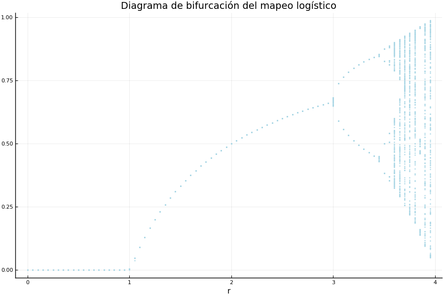

```julia
plot(p)
```

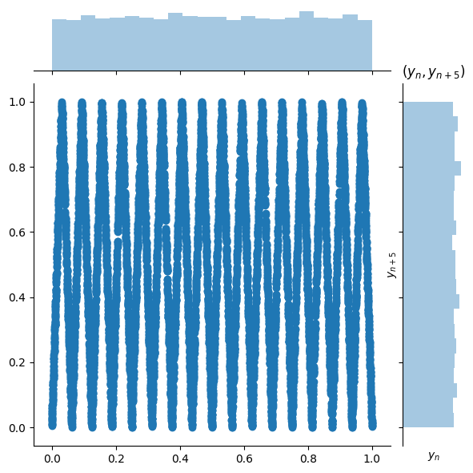

```
PyObject Text(0.5, 1, '$(y_n,y_{n+5})$')
```

```julia
m=5;Seaborn.jointplot( F_arcsin.(y[1:(n-m)]), F_arcsin.([ y[i+m] for i in 1:(n-m) ])  );Seaborn.xlabel("\$y_n\$");Seaborn.ylabel("\$y_{n+$(m)}\$");Seaborn.title("\$(y_n,y_{n+$(m)})\$")
```

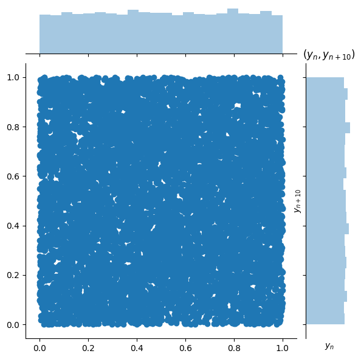

```
PyObject Text(0.5, 1, '$(y_n,y_{n+10})$')
```

```julia
m=10;Seaborn.jointplot( F_arcsin.(y[1:(n-m)]), F_arcsin.([ y[i+m] for i in 1:(n-m) ])  );Seaborn.xlabel("\$y_n\$");Seaborn.ylabel("\$y_{n+$(m)}\$");Seaborn.title("\$(y_n,y_{n+$(m)})\$")
```

Hay diversas baterías de pruebas para corrobirar que una serie de número pseudo aleatorios tienen alta probabilidad de haber sido generada por la distribución Uniforme.

```
- Pruebas Die hard (duro de matar)
- Pruebas TestU01
- Pruebas Die Harder (aún más duro de matar)
```

[figure not shown]

## Simulación

Dando por hecho que podemos generar variables aleatorias con distribución Uniforme(0,1), estudiaremos una variedad de algoritmos para generas variables aleatorias con distintas distribuciones.

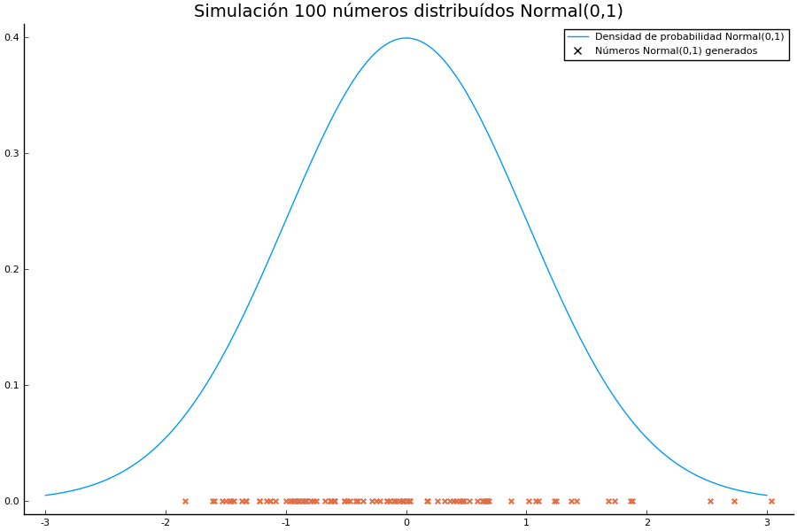

```julia
plot(p)
```

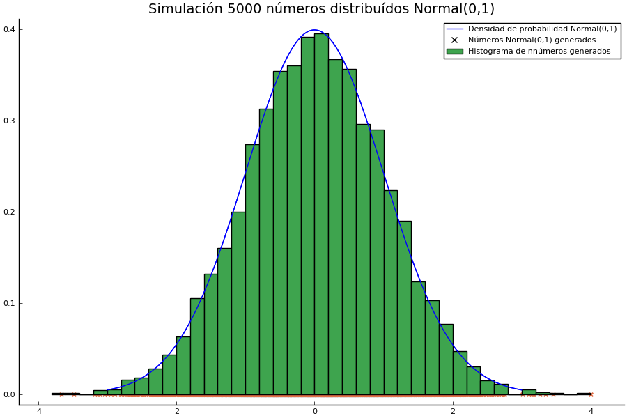

```julia
plot(p)
```

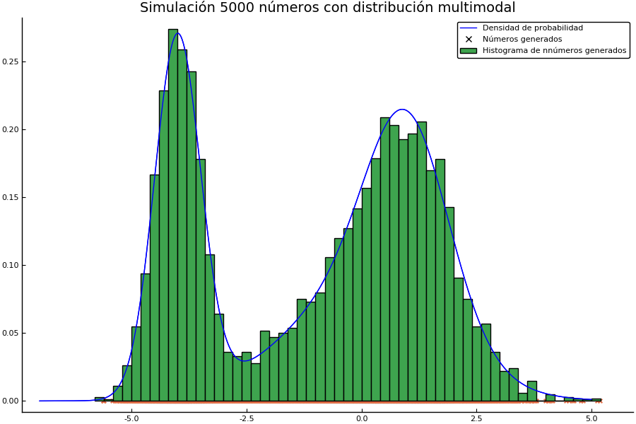

```julia
plot(p)
```

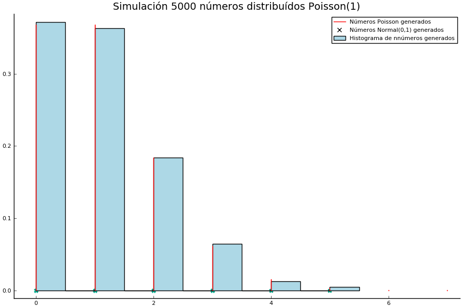

```julia
plot(p)
```

## Métodos Monte-Carlo

Podemos pensar el método Monte-Carlo como un esquema numérico para calcular integrales basado en la ley de los grandes números. Por ejemplo si $X_1, X_2, \ldots , X_n \stackrel{\text{i.i.d}}{\sim}\text{Uniforme}(0,1)$ y se tiene $f:[0,1]\rightarrow \mathbb{R}$ entonces

\begin{align*} \frac{f(X_1)+f(X_2)+\ldots + f(X_n)}{n} \stackrel{ \longrightarrow}{ _{n\to \infty} } \int_0^1 f(x)\mathrm{d}x \end{align*}

Probablemente esta metodología ya la conocen. Un ejemplo clásico es el experimento de las agujas de Buffon

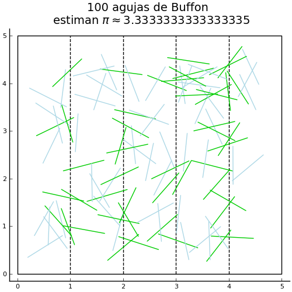

```julia
plot(p)
```

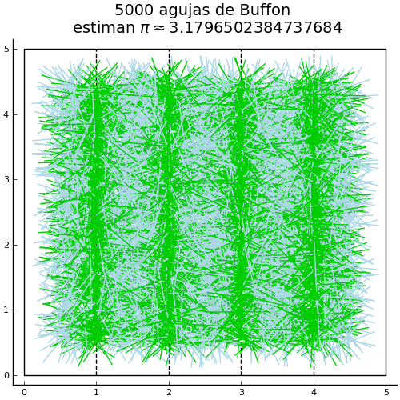

```julia
plot(p)
```

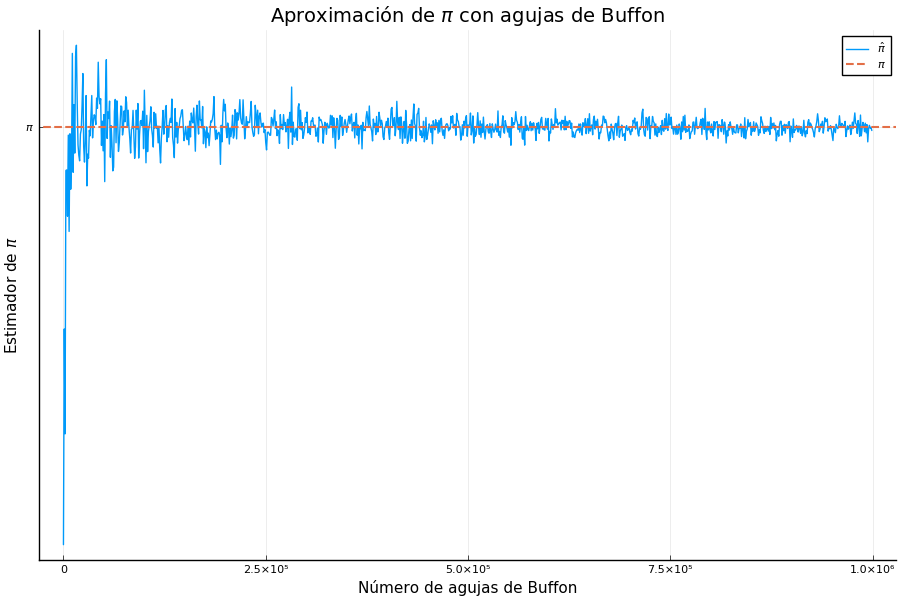

```julia
plot(p)
```

Podemos considera $\left\{ U^{(1)}_i \right\}\stackrel{\text{i.i.d.}}{\sim}\text{Uniforme}(-1,1)$, $\left\{ U^{(2)}_i \right\}\stackrel{\text{i.i.d.}}{\sim}\text{Uniforme}(-1,1)$ con lo que $(U_i^{(1)},U_i^{(2)})$ se distribuye uniformemente en $[-1,1]\times [-1,1]$

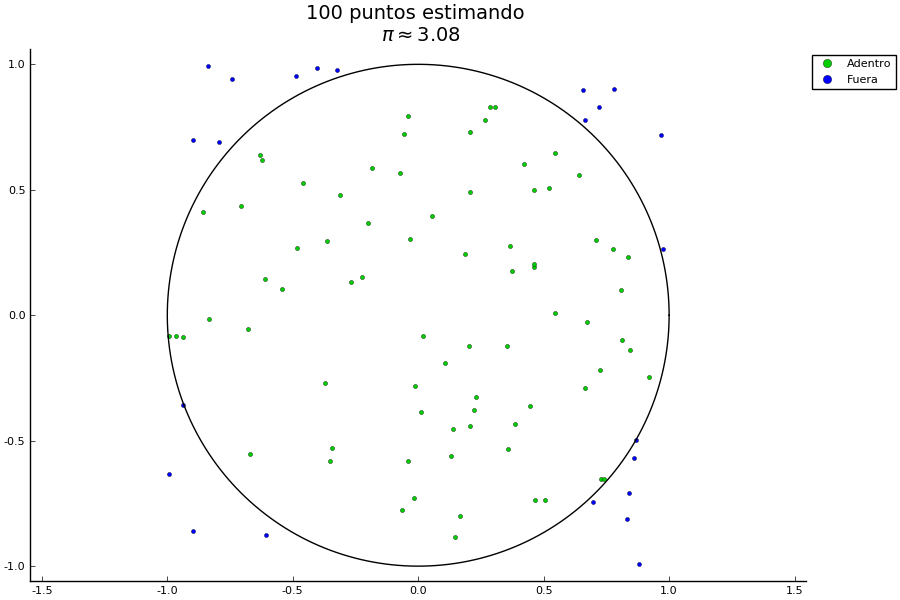

```julia
plot(p)
```

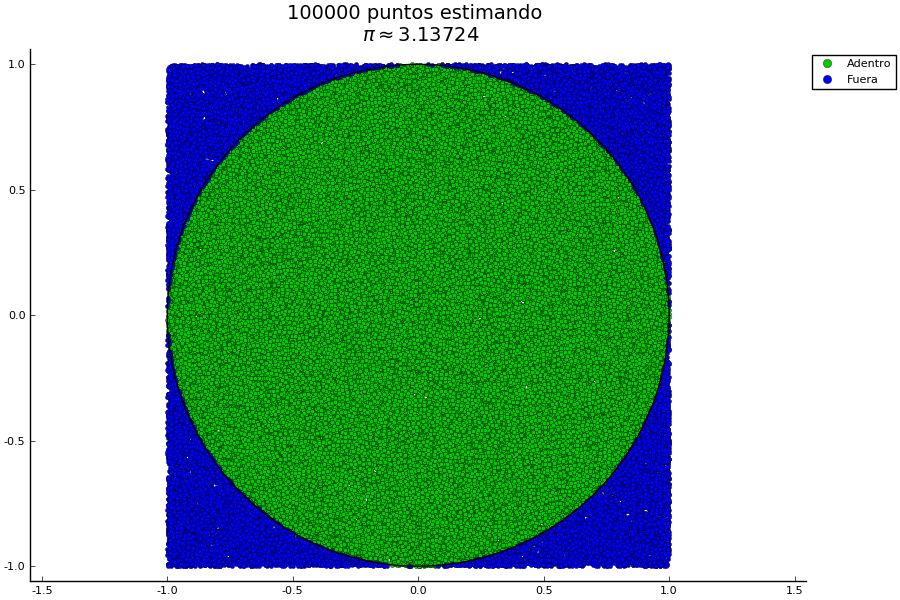

```julia
plot(p)
```

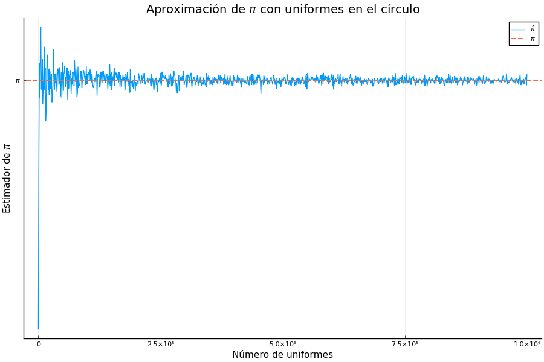

```julia
plot(p)
```

## Monte Carlo con Cadenas de Márkov (MCMC)

### Ergodicidad

Sean $\left\{ \epsilon_i \right\}_{i=1}^\infty \stackrel{\text{i.i.d.}}{\sim}\text{Normal}(0,\sigma^2)$, $\theta, x_0 \in \mathbb{R}$. Definimos la cadena auto-regresiva de orden 1, AR(1), como $\pmb{X}=\left\{ X_n \right\}_{n=0}^\infty$ tales que $X_0=x_0$ y para $n\geq 1$

\begin{equation*} X_{n+1}=\theta X_n + \epsilon _n. \end{equation*}

Para $\theta<1$ la cadena es ergódica y tiene distribución estacionaria $\text{Normal}\left(0,\frac{\sigma^2}{1-\theta^2 }\right)$.

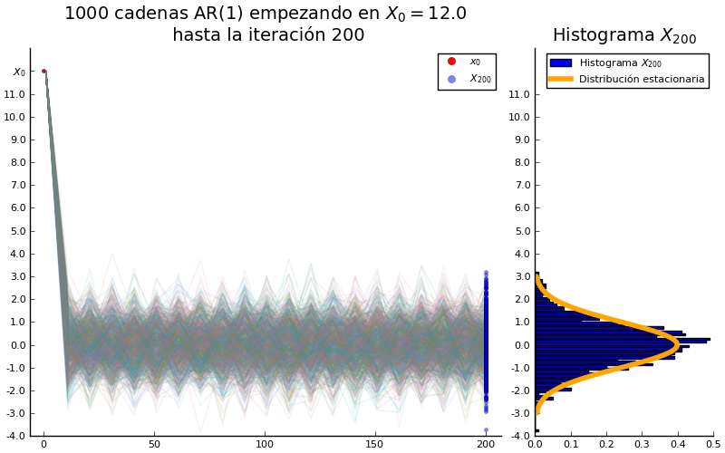

```julia
plot(p1,p2,size=(800,500),layout=l )
```

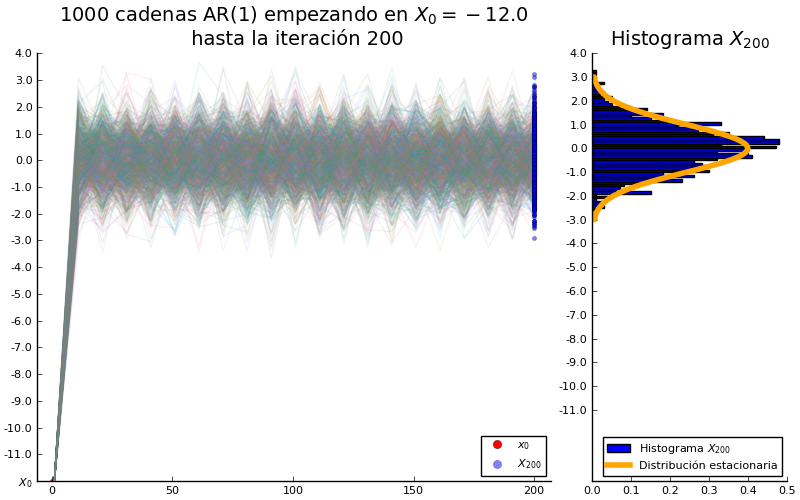

```julia
plot(p1,p2,size=(800,500),layout=l )
```

### Muestreador de Gibbs (Gibbs sampler)

Cuando se conocen todas las distribuciones condicionales de un modelo probabilístico es posible implementar un muestreador de Gibbs que tiene como distribución invariante/estacionaria la distribución conjunta de interés. Por ejemplo consideramos el siguiente modelo

\begin{align*} X_i & \; | \; \mu,\, \sigma^2 \sim \text{Normal}(\mu,\sigma) \\ \left( \mu, \sigma^2 \right) & \sim \text{Normal-InverseGamma}( \mu_0, \nu, \alpha , \beta) \end{align*}

o equivalentemente

\begin{align*} X_i & \; | \; \mu,\, \sigma^2 \sim \text{Normal}(\mu,\sigma) \\ \mu & \; | \; \sigma^2 \sim \text{Normal} \left( \mu_0 , \frac{\sigma^2}{\nu } \right) \\ \sigma^2 & \sim \text{Gamma-Inversa}\left( \alpha, \beta \right) \end{align*}

Dada observaciones $\pmb{X}=(X_1,X_2, \ldots , X_n)$ tenemos que

\begin{equation*} \mu|\sigma^2, X \sim \text{Normal}\left( \mu_n, \frac{\sigma^2}{\nu_n} \right) \end{equation*}

y \begin{equation*} \sigma^2 | \mu, X \sim \Gamma^{-1}\left( \alpha_n + 0.5, \frac{2\beta_n + \nu_n (\mu-\mu_n)^2}{2} \right). \end{equation*}

Por lo que se puede implementar el muestreador de Gibbs

```julia
gif(anim_bibbs, "gibbs_anim.gif", fps = 2)
```

```
┌ Info: Saved animation to
│   fn = /home/workstation/Documents/Simulacion/gibbs_anim.gif
└ @ Plots /home/workstation/.julia/packages/Plots/Iuc9S/src/animation.jl:95
```

[figure not shown]

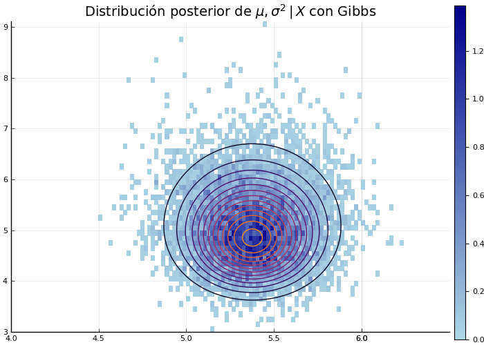

```julia
plot(p,size=(700,500))
```

### Muestreador de Metropolis-Hastings

```julia
gif(anim_metro, "metro_anim.gif", fps = 30)
```

```
┌ Info: Saved animation to
│   fn = /home/workstation/Documents/Simulacion/metro_anim.gif
└ @ Plots /home/workstation/.julia/packages/Plots/Iuc9S/src/animation.jl:95
```

[figure not shown]

## Programación Probabilística

Haremos uso del lenguaje Stan

[figure not shown]

https://mc-stan.org/

## Aplicaciones de simulación estocástica

```
- Inferencia Bayesiana
- Métodos Monte-Carlo en finanzas
- Inferencia libre
```

## Técnicas de remuestreo

```
- Bootstrap
- Jack-knife
```

## Algoritmos para datos faltantes

### Ejemplos de modelos con datos faltantes

```
- Modelos con mixturas
- Modelos escondidos de Márkov
```

### Algoritmos

```
- Algoritmo EM (esperanza-maximización)
- Agoritmo de aumentación de datos
- Filtros de partículas
```

```julia
gif(anim, "puma_anim.gif", fps = 180)
```

```
┌ Info: Saved animation to
│   fn = /home/workstation/Documents/Simulacion/puma_anim.gif
└ @ Plots /home/workstation/.julia/packages/Plots/Iuc9S/src/animation.jl:95
```

[figure not shown]